# TS analysis

2023-05-06

# Preprocessing

```r
library(tidyverse)
library(readxl)
library(forecast)
library(tseries)
ibtl <- read_excel("data/IB TL Data.xlsx")
```

```r
ibtl <- ibtl %>%
  mutate(yearmonth = paste0(`Ship Year`, "-",`Ship Month`,"-01")) %>%
  mutate(date = as.Date(yearmonth)) %>%
  filter(`Pick State` %in% c("IA", "IL", "WI", "TN", "GA"))

all_ship <- ibtl %>%
  group_by(`Pick State`, date) %>%
  summarize(total_count = sum(`Shipment Count`))

GA_series <- ts(all_ship[all_ship$`Pick State`=="GA",]$total_count, frequency=12, start=c(2019,11))
IA_series <- ts(all_ship[all_ship$`Pick State`=="IA",]$total_count, frequency=12, start=c(2019,11))
IL_series <- ts(all_ship[all_ship$`Pick State`=="IL",]$total_count, frequency=12, start=c(2019,11))
WI_series <- ts(all_ship[all_ship$`Pick State`=="WI",]$total_count, frequency=12, start=c(2019,11))
TN_series <- ts(all_ship[all_ship$`Pick State`=="TN",]$total_count, frequency=12, start=c(2019,11))
```

# Exploratory Analysis

We aim to use Autoregressive Integrated Moving Average (ARIMA) models to depict the shipment time series. ARIMA models are defined for stationary time series. Therefore, we need to check stationarity before constructing models:

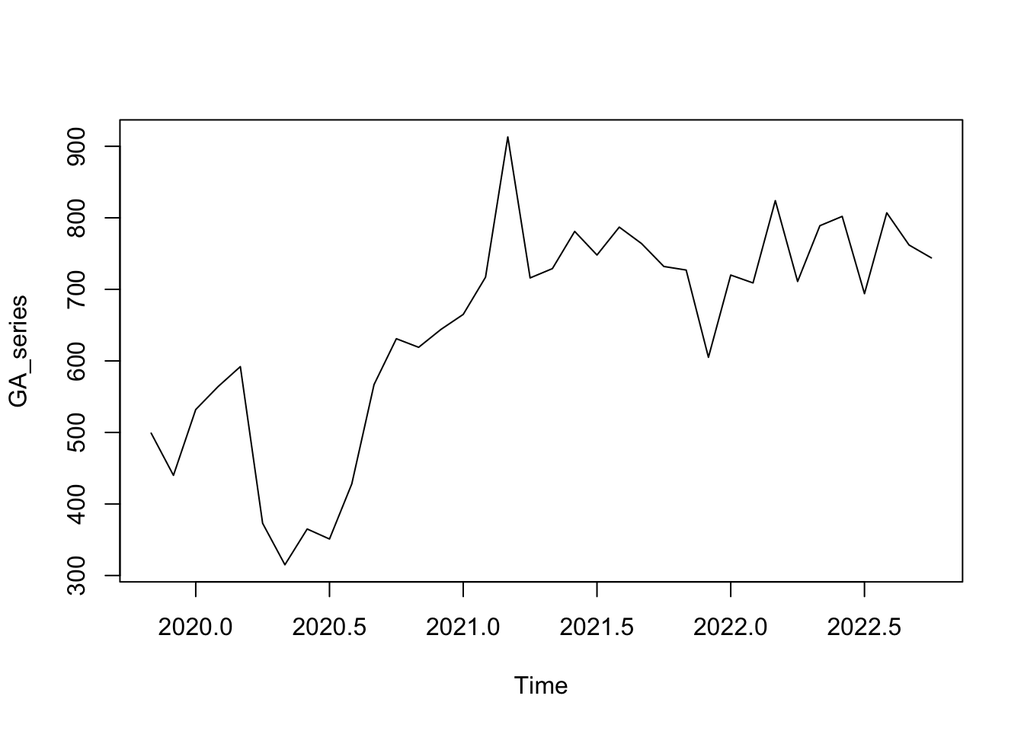

```r
plot.ts(GA_series)
```

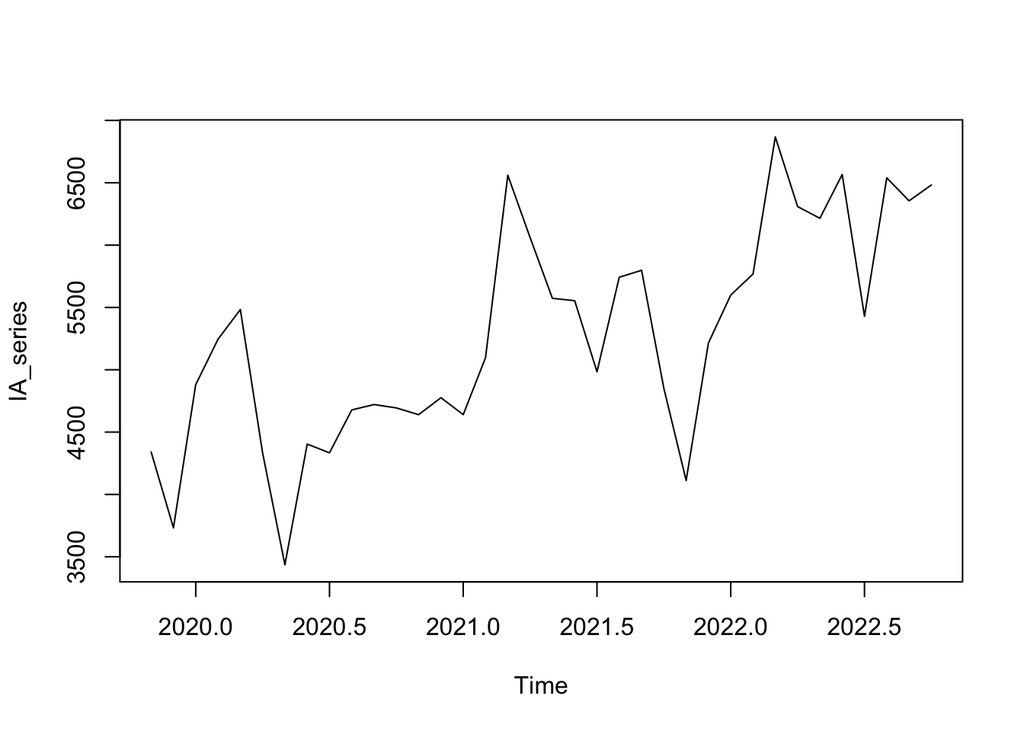

```r
plot.ts(IA_series)
```

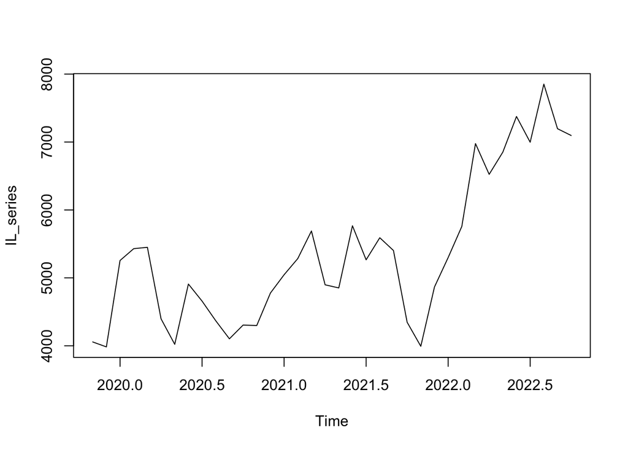

```r
plot.ts(IL_series)
```

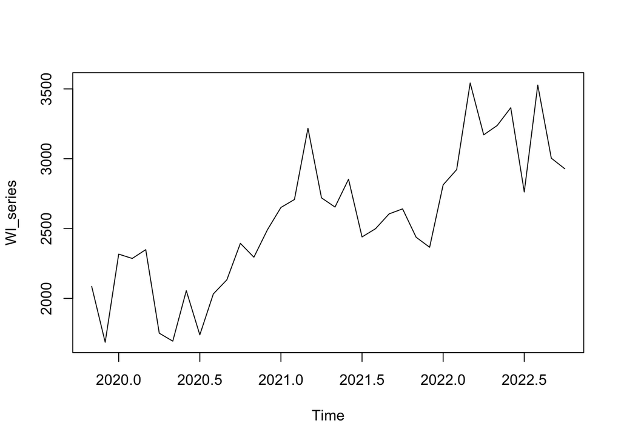

```r
plot.ts(WI_series)
```

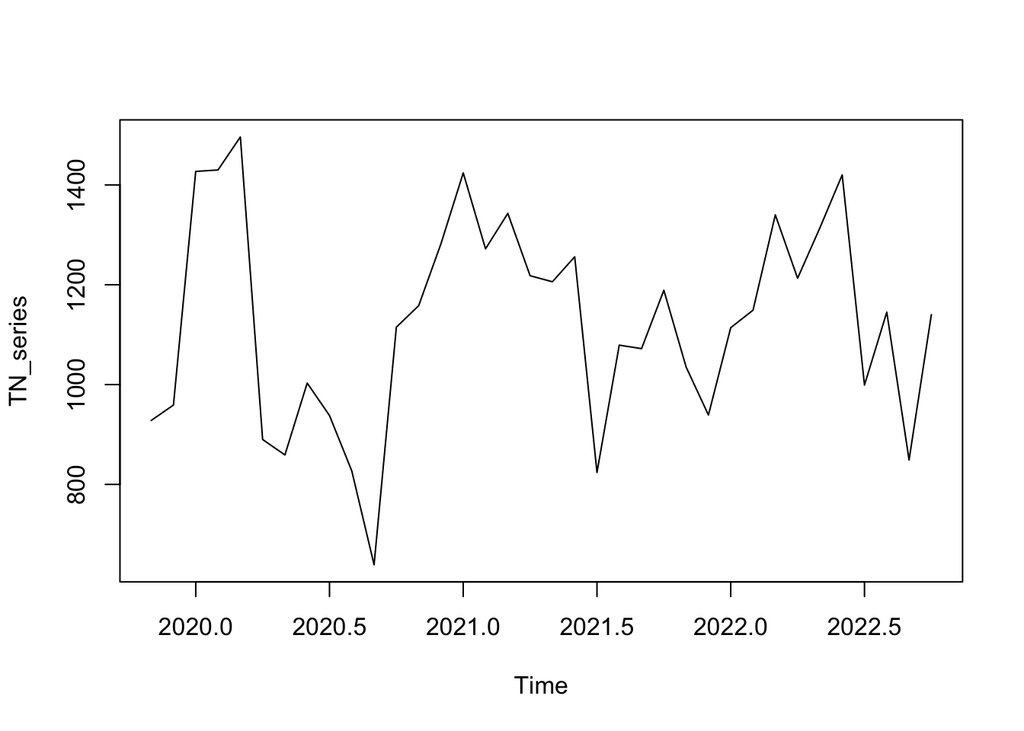

```r
plot.ts(TN_series)
```

From the time series plot we can see that overall there is upward trend in shipment from November of 2019 to October of 2022. No seasonality can be detected from the plot. However, the series does not show stationarity, so we need to difference:

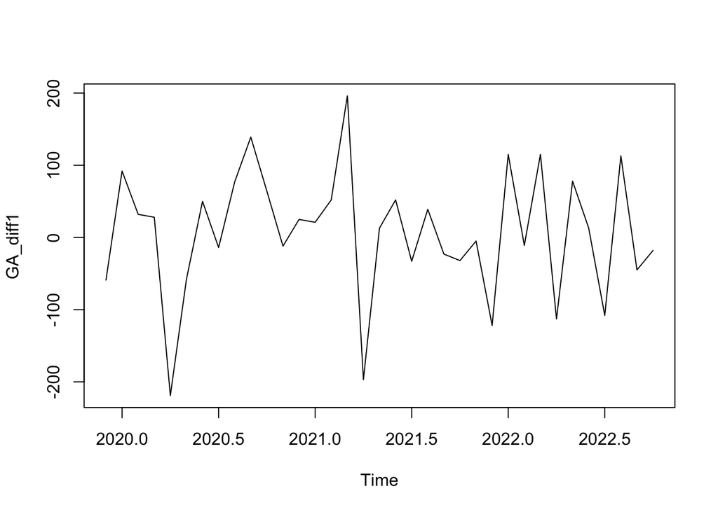

```r
GA_diff1 <- diff(GA_series, differences=1)
plot.ts(GA_diff1)
```

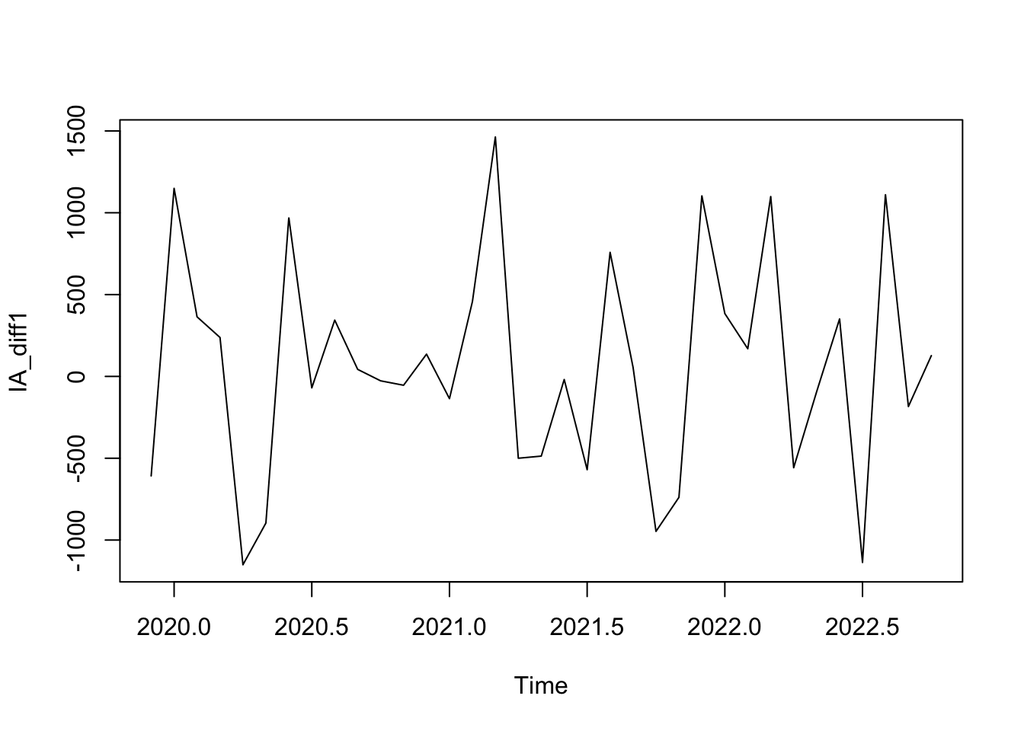

```r
IA_diff1 <- diff(IA_series, differences=1)
plot.ts(IA_diff1)
```

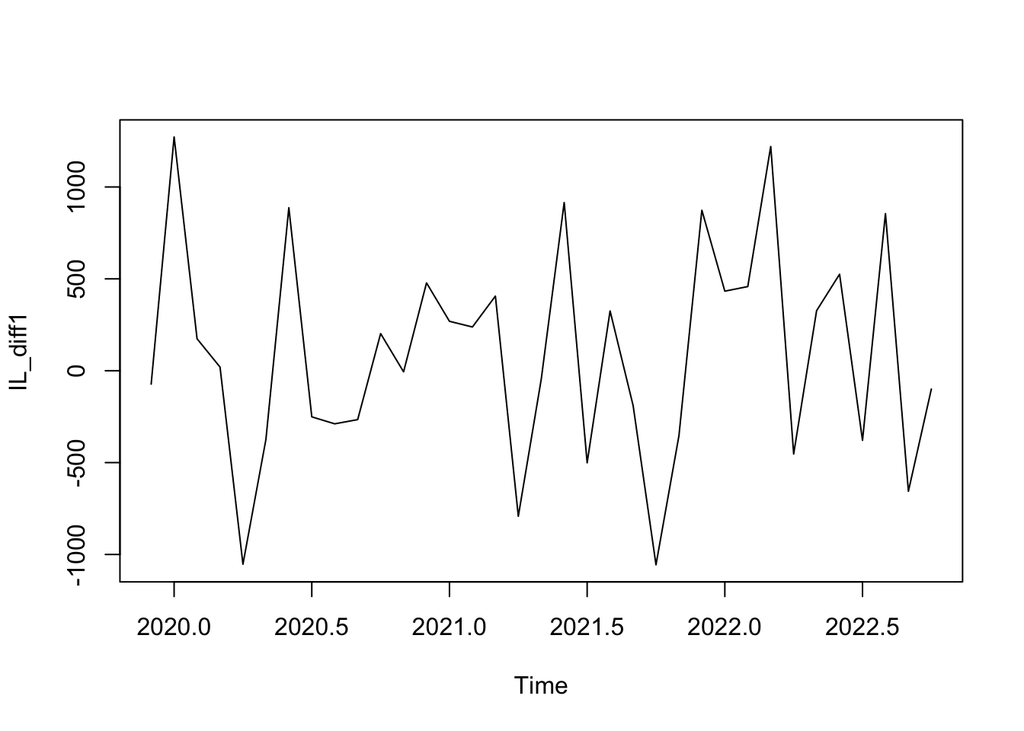

```r
IL_diff1 <- diff(IL_series, differences=1)
plot.ts(IL_diff1)
```

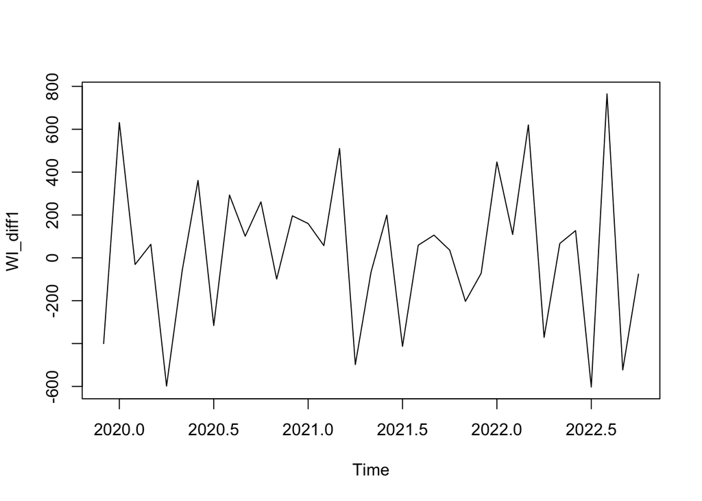

```r
WI_diff1 <- diff(WI_series, differences=1)
plot.ts(WI_diff1)
```

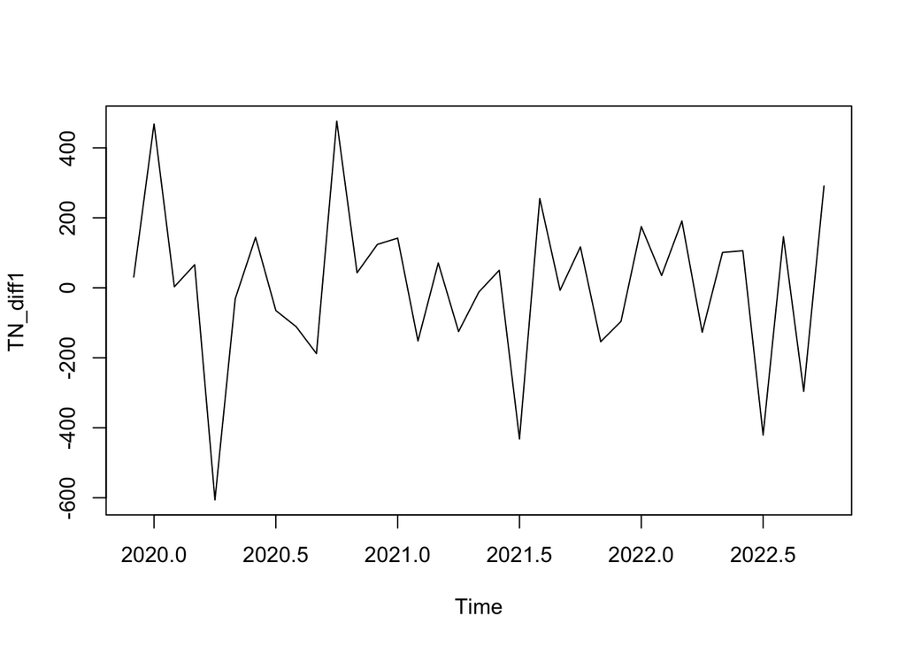

```r
TN_diff1 <- diff(TN_series, differences=1)
plot.ts(TN_diff1)
```

The resulting time series of first differences (above) gives us a stationary time series. However, a formal test, Augmented Dickey-Fuller Test can also be applied to illustrate stationarity:

```r
adf.test(GA_diff1)
```

```
##
##  Augmented Dickey-Fuller Test
##
## data:  GA_diff1
## Dickey-Fuller = -3.3707, Lag order = 3, p-value = 0.07797
## alternative hypothesis: stationary
```

```r
adf.test(IA_diff1)
```

```
##
##  Augmented Dickey-Fuller Test
##
## data:  IA_diff1
## Dickey-Fuller = -5.2993, Lag order = 3, p-value = 0.01
## alternative hypothesis: stationary
```

```r
adf.test(IL_diff1)
```

```
##
##  Augmented Dickey-Fuller Test
##
## data:  IL_diff1
## Dickey-Fuller = -4.6407, Lag order = 3, p-value = 0.01
## alternative hypothesis: stationary
```

```r
adf.test(WI_diff1)
```

```
##
##  Augmented Dickey-Fuller Test
##
## data:  WI_diff1
## Dickey-Fuller = -3.5017, Lag order = 3, p-value = 0.05901
## alternative hypothesis: stationary
```

```r
adf.test(TN_diff1)
```

```
##
##  Augmented Dickey-Fuller Test
##
## data:  TN_diff1
## Dickey-Fuller = -4.3231, Lag order = 3, p-value = 0.01
## alternative hypothesis: stationary
```

We reject the null hypothesis for IA, IL and TN, because the p-value is smaller than 0.05. This indicates that the time series is stationary. To put it another way, the first difference does not have time-dependent structure and thus exhibits constant variance over time.

But this is not the case for GA and WI, so we need the second difference for them and conduct Augmented Dickey-Fuller Test again. The results suggest that the second difference is stationary.

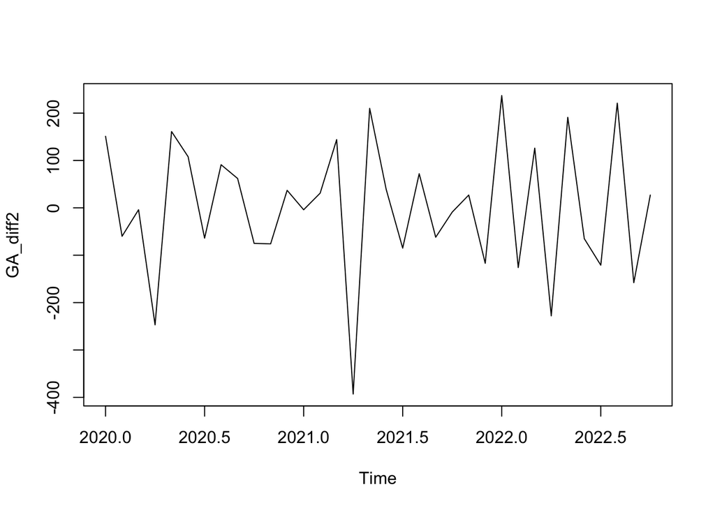

```r
GA_diff2 <- diff(GA_series, differences=2)
plot.ts(GA_diff2)
```

```r
adf.test(GA_diff2)
```

```
##
##  Augmented Dickey-Fuller Test
##
## data:  GA_diff2
## Dickey-Fuller = -5.0524, Lag order = 3, p-value = 0.01
## alternative hypothesis: stationary
```

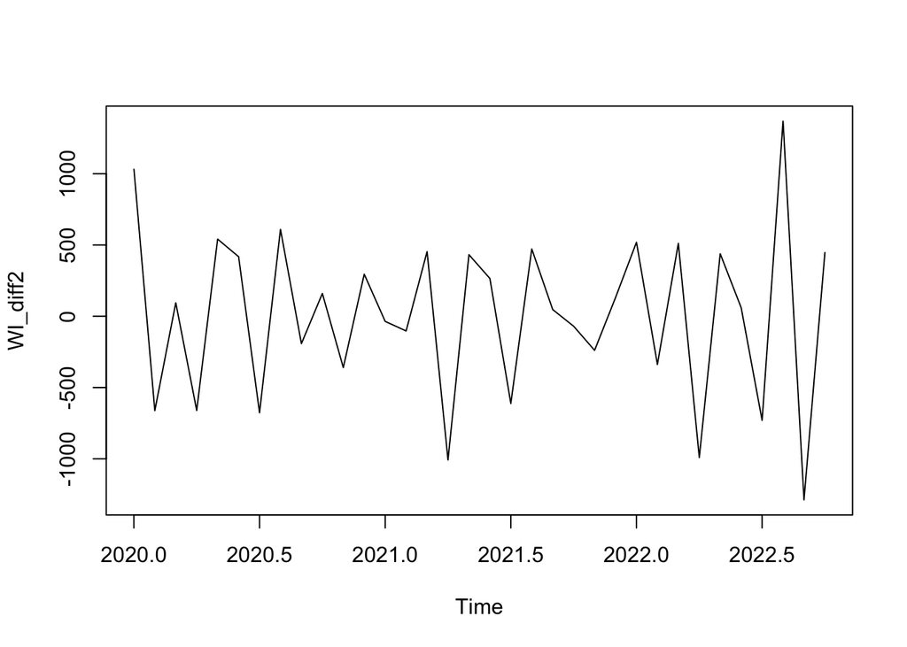

```r
WI_diff2 <- diff(WI_series, differences=2)
plot.ts(WI_diff2)
```

```r
adf.test(WI_diff2)
```

```
##
##  Augmented Dickey-Fuller Test
##
## data:  WI_diff2
## Dickey-Fuller = -5.8074, Lag order = 3, p-value = 0.01
## alternative hypothesis: stationary
```

# Select ARIMA Models

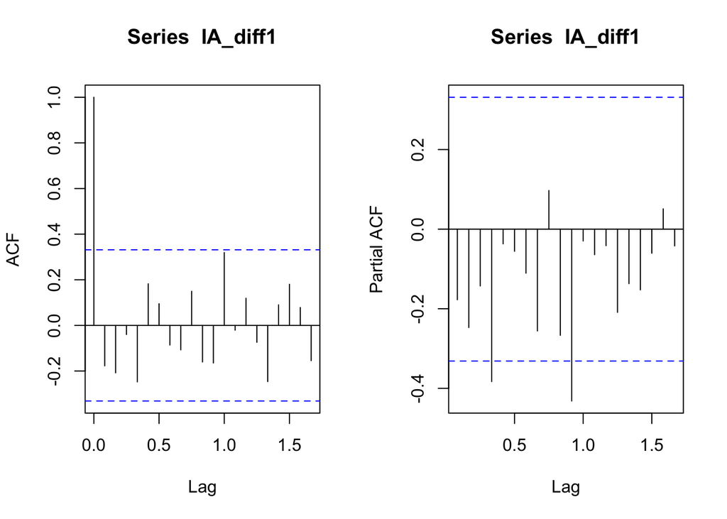

```r
par(mfrow = c(1,2))
acf(IA_diff1, lag.max=20)
pacf(IA_diff1, lag.max=20)
```

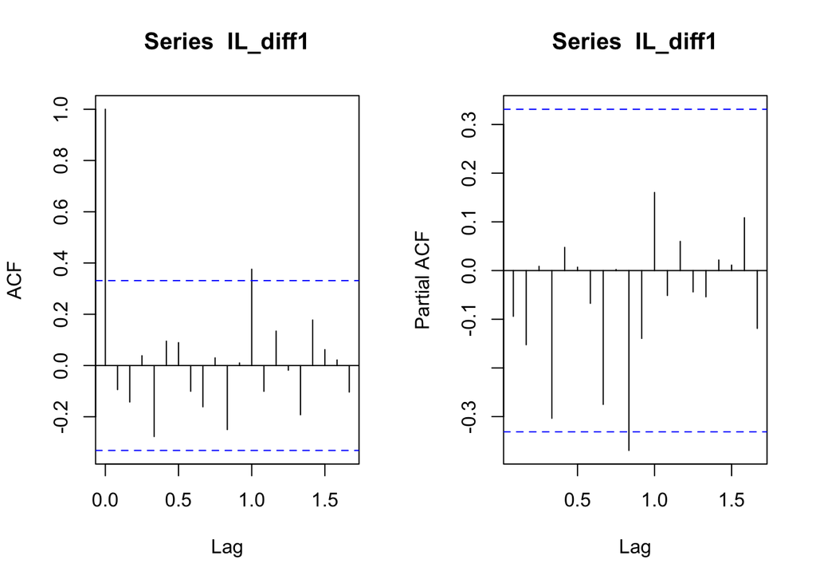

```r
par(mfrow = c(1,2))
acf(IL_diff1, lag.max=20)
pacf(IL_diff1, lag.max=20)
```

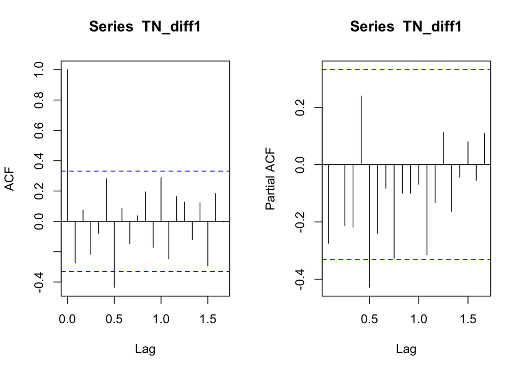

```r
par(mfrow = c(1,2))
acf(TN_diff1, lag.max=20)
pacf(TN_diff1, lag.max=20)
```

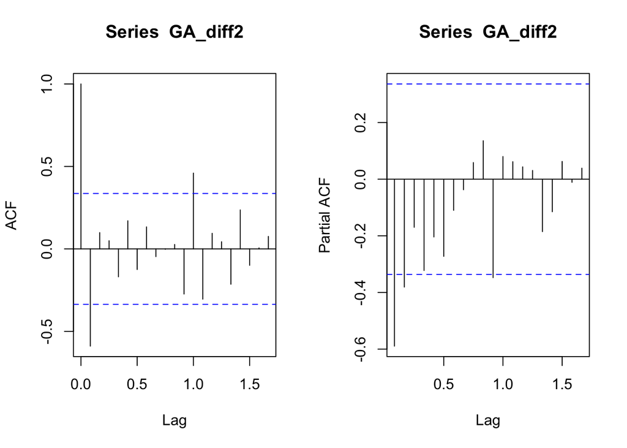

```r
par(mfrow = c(1,2))
acf(GA_diff2, lag.max=20)
pacf(GA_diff2, lag.max=20)
```

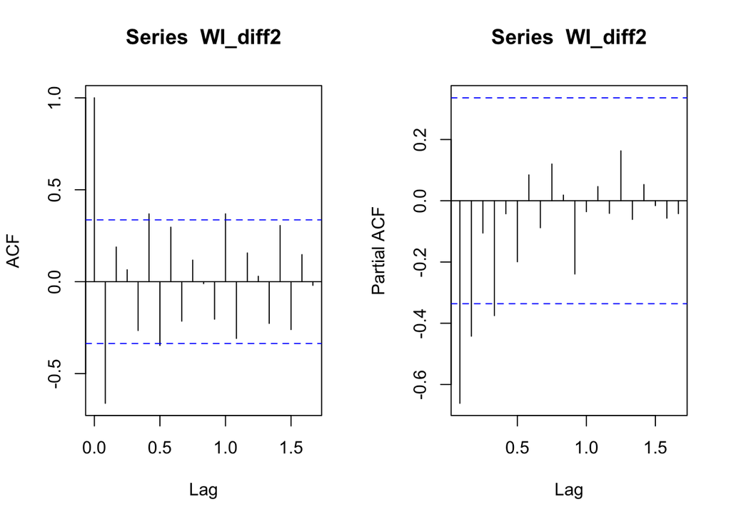

```r
par(mfrow = c(1,2))
acf(WI_diff2, lag.max=20)
pacf(WI_diff2, lag.max=20)
```

```r
IAarima <- Arima(IA_diff1, order = c(0,1,0))
summary(IAarima)
```

```
## Series: IA_diff1
## ARIMA(0,1,0)
##
## sigma^2 = 1079500:  log likelihood = -284.41
## AIC=570.82   AICc=570.94   BIC=572.34
##
## Training set error measures:
##                    ME     RMSE      MAE      MPE     MAPE    MASE       ACF1
## Training set 20.98263 1024.039 798.1602 2.612774 319.9088 1.39932 -0.4608836
```

```r
ILarima <- Arima(IL_diff1, order = c(0,1,0))
summary(ILarima)
```

```
## Series: IL_diff1
## ARIMA(0,1,0)
##
## sigma^2 = 761164:  log likelihood = -278.47
## AIC=558.94   AICc=559.06   BIC=560.46
##
## Training set error measures:
##                      ME    RMSE      MAE      MPE     MAPE     MASE       ACF1
## Training set -0.7735143 859.893 711.9164 88.97244 326.6217 1.647126 -0.4747795
```

```r
TNarima <- Arima(TN_diff1, order = c(0,1,0))
summary(TNarima)
```

```
## Series: TN_diff1
## ARIMA(0,1,0)
##
## sigma^2 = 128734:  log likelihood = -248.26
## AIC=498.52   AICc=498.64   BIC=500.04
##
## Training set error measures:
##                    ME     RMSE     MAE       MPE     MAPE     MASE       ACF1
## Training set 7.429457 353.6328 283.658 -341.2871 788.0785 1.648758 -0.6132453
```

```r
GAarima <- Arima(GA_diff2, order = c(2,1,0))
summary(GAarima)
```

```
## Series: GA_diff2
## ARIMA(2,1,0)
##
## Coefficients:
##           ar1      ar2
##       -1.1266  -0.5782
## s.e.   0.1398   0.1409
##
## sigma^2 = 21811:  log likelihood = -211.39
## AIC=428.79   AICc=429.62   BIC=433.28
##
## Training set error measures:
##                    ME   RMSE      MAE      MPE     MAPE     MASE       ACF1
## Training set -6.95715 141.02 104.8647 65.66179 216.1622 1.065108 -0.1752752
```

```r
WIarima <- Arima(WI_diff2, order = c(2,1,0))
summary(WIarima)
```

```
## Series: WI_diff2
## ARIMA(2,1,0)
##
## Coefficients:
##           ar1      ar2
##       -1.3251  -0.7361
## s.e.   0.1253   0.1340
##
## sigma^2 = 265425:  log likelihood = -253.08
## AIC=512.16   AICc=512.99   BIC=516.65
##
## Training set error measures:
##                     ME     RMSE      MAE      MPE     MAPE     MASE       ACF1
## Training set -39.13843 491.9402 381.4785 72.81933 142.9184 1.120198 -0.1093073
```

# Forecasting

```r
IAforecasts <- forecast::forecast(IAarima, h=5)
IAforecasts
```

```
##          Point Forecast     Lo 80    Hi 80     Lo 95    Hi 95
## Nov 2022            127 -1204.519 1458.519 -1909.382 2163.382
## Dec 2022            127 -1756.052 2010.052 -2752.880 3006.880
## Jan 2023            127 -2179.258 2433.258 -3400.118 3654.118
## Feb 2023            127 -2536.038 2790.038 -3945.765 4199.765
## Mar 2023            127 -2850.367 3104.367 -4426.489 4680.489
```

```r
ILforecasts <- forecast::forecast(ILarima, h=5)
IAforecasts
```

```
##          Point Forecast     Lo 80    Hi 80     Lo 95    Hi 95
## Nov 2022            127 -1204.519 1458.519 -1909.382 2163.382
## Dec 2022            127 -1756.052 2010.052 -2752.880 3006.880
## Jan 2023            127 -2179.258 2433.258 -3400.118 3654.118
## Feb 2023            127 -2536.038 2790.038 -3945.765 4199.765
## Mar 2023            127 -2850.367 3104.367 -4426.489 4680.489
```

```r
TNforecasts <- forecast::forecast(TNarima, h=5)
TNforecasts
```

```
##          Point Forecast     Lo 80     Hi 80      Lo 95     Hi 95
## Nov 2022            291 -168.8151  750.8151  -412.2265  994.2265
## Dec 2022            291 -359.2767  941.2767  -703.5124 1285.5124
## Jan 2023            291 -505.4231 1087.4231  -927.0240 1509.0240
## Feb 2023            291 -628.6302 1210.6302 -1115.4530 1697.4530
## Mar 2023            291 -737.1778 1319.1778 -1281.4622 1863.4622
```

```r
GAforecasts <- forecast::forecast(GAarima, h=5)
GAforecasts
```

```
##          Point Forecast     Lo 80    Hi 80     Lo 95    Hi 95
## Nov 2022       37.71482 -151.5524 226.9820 -251.7443 327.1740
## Dec 2022      -81.32681 -272.1057 109.4521 -373.0979 210.4443
## Jan 2023       46.59506 -172.0605 265.2506 -287.8097 380.9998
## Feb 2023      -28.69543 -262.4898 205.0989 -386.2530 328.8622
## Mar 2023      -17.83638 -254.1262 218.4535 -379.2105 343.5378
```

```r
WIforecasts <- forecast::forecast(WIarima, h=5)
WIforecasts
```

```
##          Point Forecast      Lo 80      Hi 80      Lo 95     Hi 95
## Nov 2022      103.06183  -557.1860  763.30963  -906.7001 1112.8237
## Dec 2022     -718.34873 -1412.6139  -24.08352 -1780.1357  343.4383
## Jan 2023      623.29326  -208.8016 1455.38808  -649.2859 1895.8725
## Feb 2023     -549.87832 -1408.1788  308.42221 -1862.5357  762.7791
## Mar 2023       17.09821  -842.3148  876.51123 -1297.2606 1331.4570
```

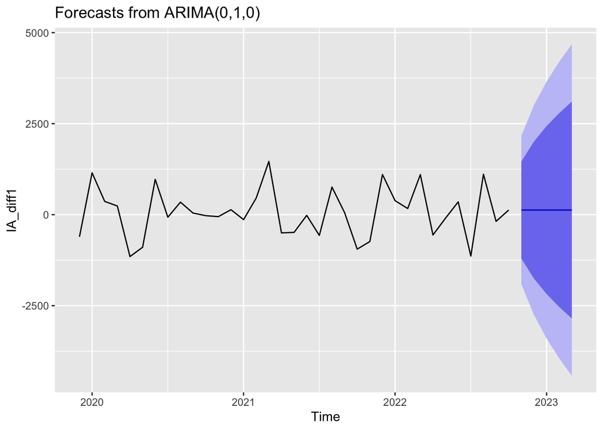

```r
autoplot(IAforecasts)
```

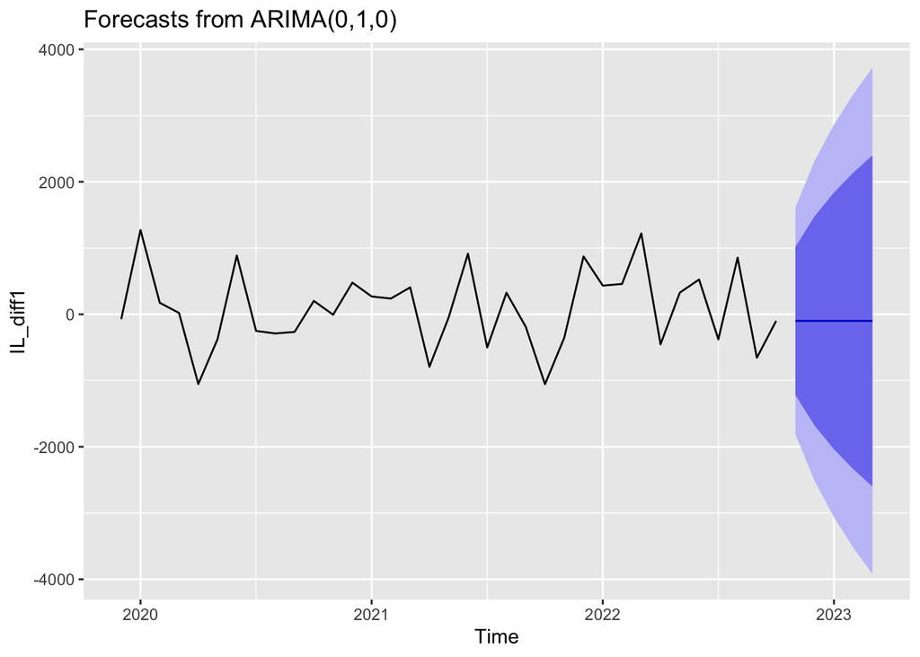

```r
autoplot(ILforecasts)
```

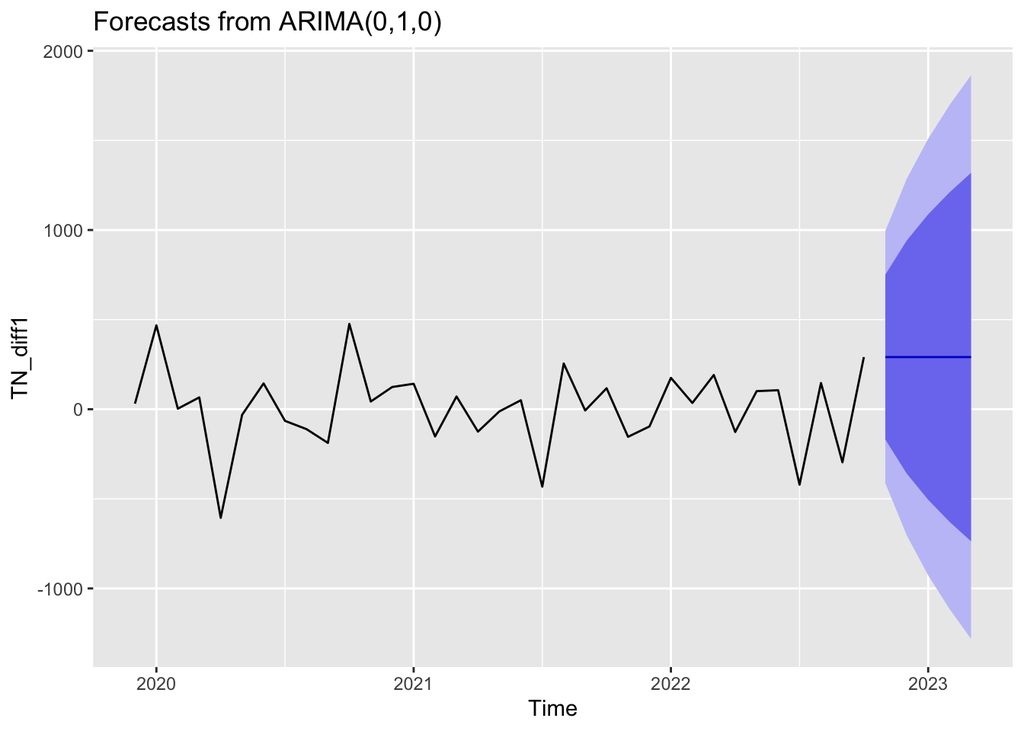

```r
autoplot(TNforecasts)
```

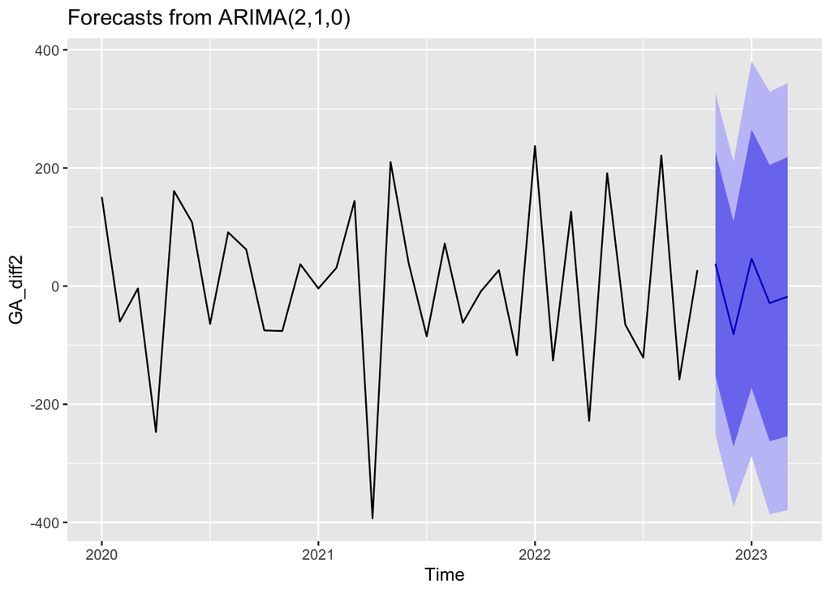

```r
autoplot(GAforecasts)
```

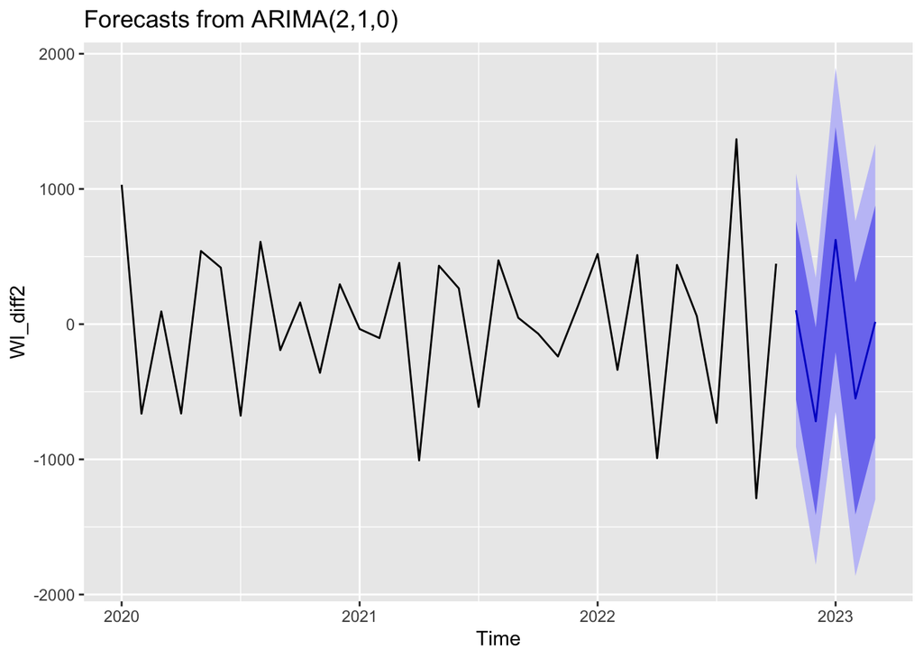

```r
autoplot(WIforecasts)
```